# Reproducible Research: Peer Assessment 1

## Loading and preprocessing the data

```r
    data  <- read.csv(unzip("activity.zip", "activity.csv"))
```

The field *date* is a factor. I convert this field to the proper type:

```r
    data$date  <- as.Date(data$date, format = "%Y-%m-%d")
```

I’m adding a new field *hour* geting it from interval:

```r
    data$hour  <- data$interval /100 + (data$interval %% 100) /60
```

Now, it’s good to have a general ideas:

```r
    summary(data)
```

```
##      steps             date               interval           hour
##  Min.   :  0.00   Min.   :2012-10-01   Min.   :   0.0   Min.   : 0.00
##  1st Qu.:  0.00   1st Qu.:2012-10-16   1st Qu.: 588.8   1st Qu.: 6.25
##  Median :  0.00   Median :2012-10-31   Median :1177.5   Median :12.23
##  Mean   : 37.38   Mean   :2012-10-31   Mean   :1177.5   Mean   :12.23
##  3rd Qu.: 12.00   3rd Qu.:2012-11-15   3rd Qu.:1766.2   3rd Qu.:18.22
##  Max.   :806.00   Max.   :2012-11-30   Max.   :2355.0   Max.   :24.47
##  NA's   :2304
```

## What is mean total number of steps taken per day?

We calculate the number of steps per day, with the use of function aggregate:

```r
    stepsPerDay  <-  aggregate(data$steps, by = list( data$date), FUN = sum)
    names(stepsPerDay)  <-  c("date", "steps")
```

And here you have the histogram:

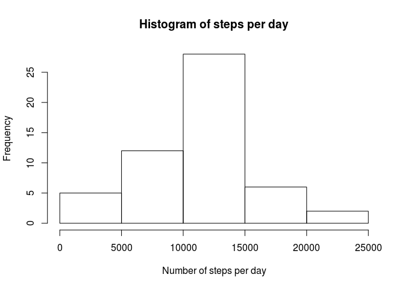

```r
    hist(stepsPerDay$steps, xlab = "Number of steps per day", main = "Histogram of steps per day")
```

The media of steps per day is 10766.19 and the median is 10765.

## What is the average daily activity pattern?

I create a new data frame called *stepsPerInterval* where I calculate the mean of steps along all days. Notice that I’ve removed NAs. Otherwise the mean should not be calculated:

```r
    stepsPerInterval  <-  aggregate(data$steps, by = list( data$hour), FUN = mean, na.rm = TRUE)
    names(stepsPerInterval)  <- c("hour", "steps")
```

Then, I plot the results:

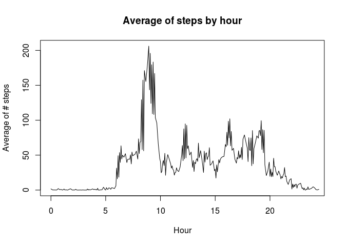

```r
    plot(stepsPerInterval$hour, stepsPerInterval$steps, type = "l", xlim = c(0, 24), main = "Average of steps by hour", xlab = "Hour", ylab = "Average of # steps")
```

## Imputing missing values

1. We don’t have information on 2304 records about *steps*.
2. We’re creating a new data frame without the NAs. The strategy is filling it with the average for this interval.

```r
    cleanData <- data
    for (i in 1:nrow(cleanData)){
        if (is.na(cleanData[i, "steps"])) {
            cleanData[i,"steps"]  <- stepsPerInterval[stepsPerInterval$hour == cleanData[i, "hour"], "steps"]
        }
    }
```

3. I recalculate *stepsPerDay*:

```r
    stepsPerDay  <-  aggregate(cleanData$steps, by = list( cleanData$date), FUN = sum)
    names(stepsPerDay)  <-  c("date", "steps")
```

4. And here you have the new histogram

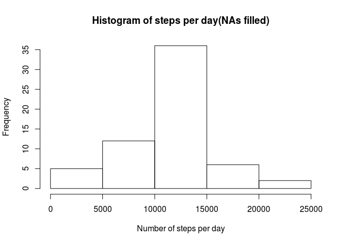

```r
    hist(stepsPerDay$steps, xlab = "Number of steps per day", main = "Histogram of steps per day(NAs filled)")
```

The number of values rounding average has increased.

## Are there differences in activity patterns between weekdays and weekends?

We introduce to the dataframe *cleanData* a new field called *weekday*. It could be a working day (Mon, Tues, Wed, Thur, Fri) or a weekend (Sat, Sun):

```r
    wday  <- factor(weekdays(cleanData$date, abbreviate = TRUE)=="dom" | weekdays(cleanData$date, abbreviate = TRUE)=="sáb", levels = c(FALSE, TRUE), labels = c("workingday", "weekend"))
    cleanData["weekday"]  <- wday
```

Recalculate activity for working day & weekend:

```r
    stepsPerInterval  <-  aggregate(cleanData$steps, by = list( cleanData$hour, cleanData$weekday), FUN = mean, na.rm = TRUE)
    names(stepsPerInterval)  <- c("hour", "weekday", "steps")
```

And ploting results:

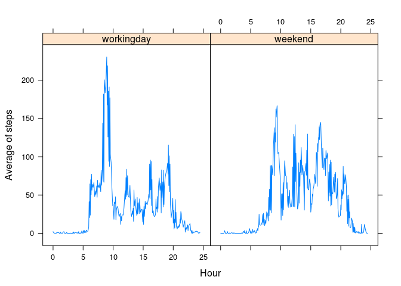

```r
    library(lattice)
    xyplot(stepsPerInterval$steps~stepsPerInterval$hour|stepsPerInterval$weekday, xlab="Hour", ylab="Average of steps", type = "l")
```